# Comparison of Algorithms Across Business Lines

# Introduction

## Models Analyzed

This notebook tests key algorithms across the different business lines. The algorithms tested include

- Mack Chain Ladder
- Bootstrap Chain Ladder
- GP on Incremental Loss Ratios with hurdle model
- GP on Incremental Loss Ratios with hurdle model and virtual data points
- GP on Incremental Loss Ratios with hurdle model using multi-company model

## Stan Programs

This notebook runs Stan programs iteratively. It is important for speed purposes that each of the Stan programs are pre-compiled. Once the code is compiled, Stan stores a compiled version. But sometimes this routine fails if the compilation is done as part of a subroutine. Thus it is important that the following code be run once MANUALLY before running the rest of the program.

```r
stanMod <- stan_model(file=paste0(stan_dir, "gp_compound_mean_het_05.stan"))
```

[output not shown]

```r
stanMod <- stan_model(file=paste0(stan_dir,  "gp_hurdle_phiapprox_05.stan"))
```

[output not shown]

```r
stanMod <- stan_model(file=paste0(stan_dir,  "gp_hurdle_multi_co_phiapprox_05.stan"))
```

[output not shown]

```r
stanMod <- stan_model(file=paste0(stan_dir,  "gp_hurdle_multi_co_indiv_rho_05.stan"))
```

[output not shown]

### Tuning of Rho

The priors for rho are determined using the Betancourt method. This fits an inverse gamma distribution to rho, such that the each of probability that the length scale of rho is less than the minimum or or greater than the maximum is $\alpha \%$. In the report, we set $\alpha=0.001$ (the tail probability on each side). We work with the scaled accident year and development lag input dimensions, which have the same minimum and maximum length scales.

##### Tuning for ILR Models

ILR models train on 10x10 squares of incremental claims

- The minimum length scale is: 0.3302891
- The maximum length scale is: 2.9726022
- The inverse gamma prior parameters for rho (for each of the AccidentYear and DevelopmentLag dimensions are) are: 8.685, 6.829

# Multi-Company ILR Models

## Multi Company GP on Incremental Loss Ratios with Hurdle Model

| metric | wkcomp |
| --- | --- |
| RMSE Claims | 44665.1502 |
| RMSE LR | 0.0673 |
| RMSE Weighted LR | 0.0464 |
| Coverage 90 | 1.0000 |
| CRPS1 | 122921.0567 |
| NLPD | 106.2969 |
| KS Rejection Level | 0.5633 |
| KS D | 0.4830 |
| KS Result | 0.0000 |
| Valid Count | 5.0000 |

| Step_Ahead | wkcomp |
| --- | --- |
| 1 | 38026.15 |
| 2 | 39724.64 |
| 3 | 30347.32 |
| 4 | 34714.93 |
| 5 | 39032.57 |
| 6 | 46554.91 |
| 7 | 47463.82 |
| 8 | 35717.74 |
| 9 | 18811.74 |

| Step_Ahead | wkcomp |
| --- | --- |
| 1 | 0.0263 |
| 2 | 0.0386 |
| 3 | 0.0445 |
| 4 | 0.0580 |
| 5 | 0.0810 |
| 6 | 0.1422 |
| 7 | 0.2305 |
| 8 | 0.2763 |
| 9 | 0.3074 |

|  | mean | se_mean | sd | 2.5% | 25% | 50% | 75% | 97.5% | n_eff | Rhat | par | business_line |
| --- | --- | --- | --- | --- | --- | --- | --- | --- | --- | --- | --- | --- |
| 1 | 1.80714305 | 0.0245359858 | 0.347782982 | 1.2348163715 | 1.564155828 | 1.770689478 | 1.99904093 | 2.63164123 | 200.91374 | 1.0013393 | eta | wkcomp |
| 2 | 1.62438574 | 0.1359313877 | 0.511109080 | 0.9234924846 | 1.253747385 | 1.536269198 | 1.84883633 | 2.95472515 | 14.13799 | 1.0066040 | rho[1] | wkcomp |
| 3 | 1.38655432 | 0.0375850444 | 0.234519413 | 0.9649045213 | 1.224554053 | 1.378591022 | 1.53925922 | 1.85714093 | 38.93386 | 1.0268743 | rho[2] | wkcomp |
| 4 | 1.13799435 | 0.0663451805 | 0.642203859 | 0.2390123551 | 0.630482296 | 1.037754648 | 1.50028340 | 2.67532343 | 93.69730 | 1.0047294 | theta[1] | wkcomp |
| 5 | 0.87797705 | 0.0184470312 | 0.485305681 | 0.2451127453 | 0.502526818 | 0.761767296 | 1.16796018 | 2.09461000 | 692.11424 | 0.9992361 | theta[2] | wkcomp |
| 6 | 0.00424496 | 0.0004805988 | 0.003437512 | 0.0008035833 | 0.001919903 | 0.003137102 | 0.00538822 | 0.01411066 | 51.15912 | 1.0424428 | alpha | wkcomp |
| 7 | 0.04512012 | 0.0036200320 | 0.027974258 | 0.0045797906 | 0.021559156 | 0.040653282 | 0.06468816 | 0.10546587 | 59.71622 | 1.0245166 | sigma[1] | wkcomp |
| 8 | 0.10349195 | 0.0006966948 | 0.015970592 | 0.0749959634 | 0.091654864 | 0.102959768 | 0.11442053 | 0.13618705 | 525.48086 | 1.0008124 | sigma[2] | wkcomp |
| 9 | 0.12398966 | 0.0012398951 | 0.017199973 | 0.0921752922 | 0.112028393 | 0.123372668 | 0.13570144 | 0.15873043 | 192.43569 | 1.0086002 | sigma[3] | wkcomp |
| 10 | 0.15451339 | 0.0009346598 | 0.017508917 | 0.1237025415 | 0.141443649 | 0.154006789 | 0.16654576 | 0.19006646 | 350.92268 | 0.9994321 | sigma[4] | wkcomp |

[output cut: 6 more lines]

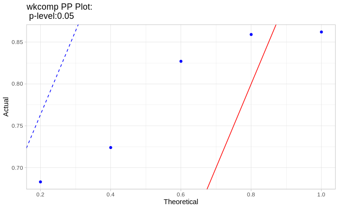

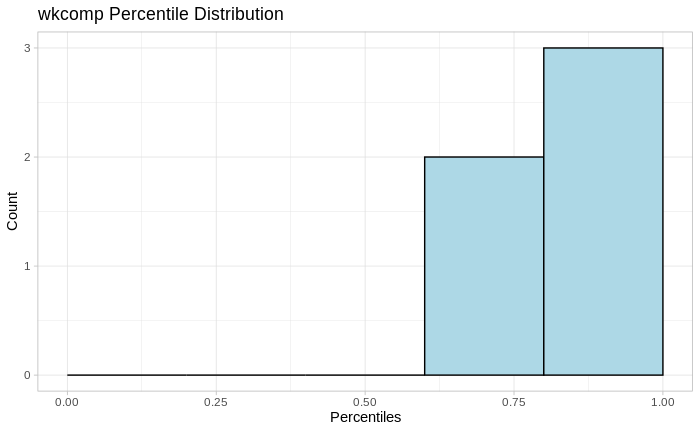

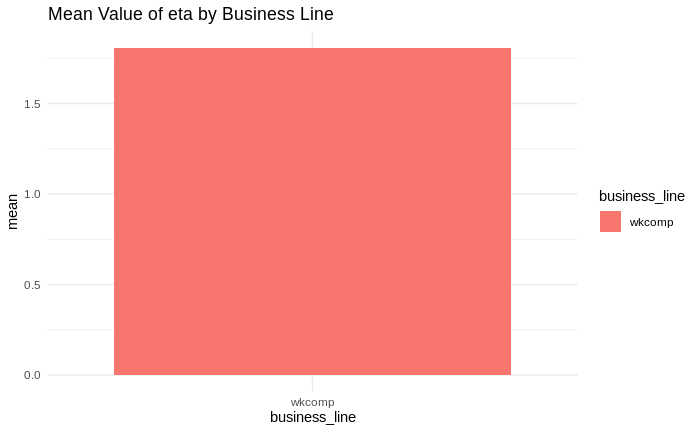

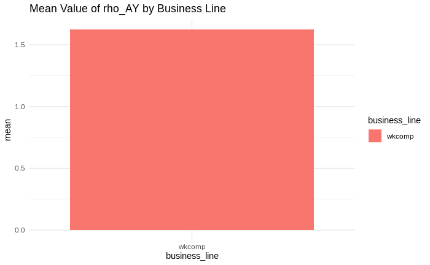

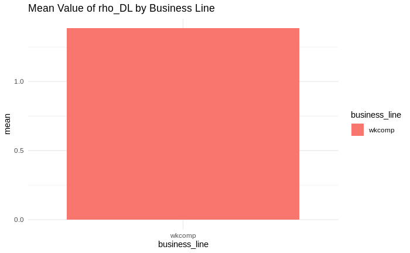

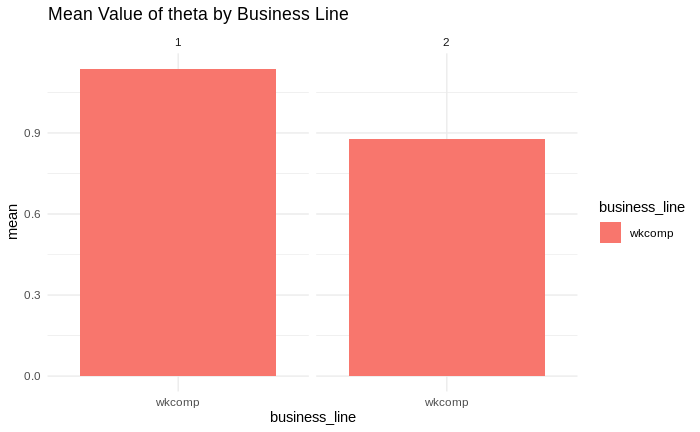

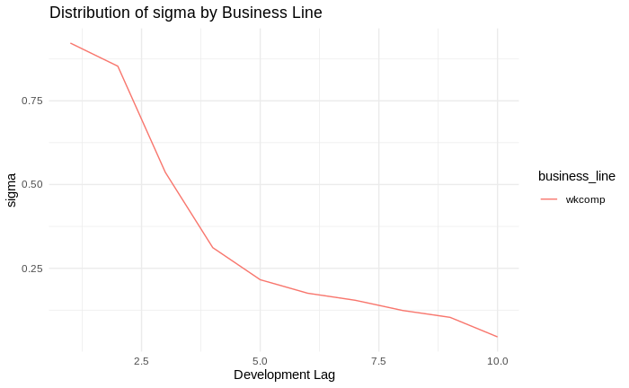

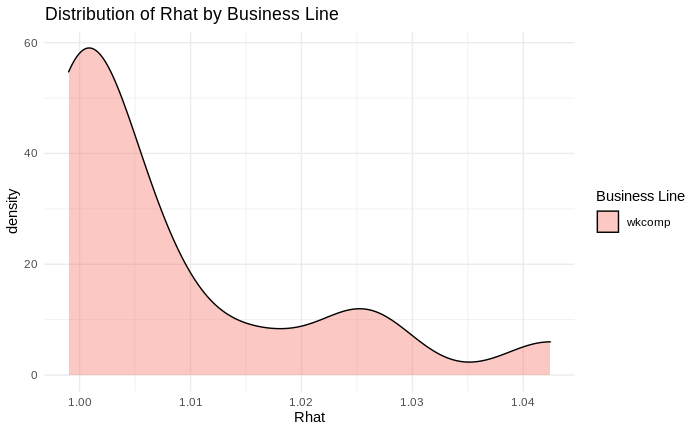

## Multi Company GP on Incremental Loss Ratios with Hurdle Model,with individual company lengthscale factor

```r
print_loss_results(res_gp_inc_hurdle_multi_co_indiv)
```

[output not shown]

# The Single Company Algorithms

## Mack Chain Ladder

| metric | wkcomp |
| --- | --- |
| RMSE Claims | 79194.9327 |
| RMSE LR | 0.0542 |
| RMSE Weighted LR | 0.0350 |
| Coverage 90 | 0.6000 |
| CRPS1 | 205748.9374 |
| NLPD | 109.3471 |
| KS Rejection Level | 0.5633 |
| KS D | 0.2633 |
| KS Result | 0.0000 |
| Valid Count | 5.0000 |

| Step_Ahead | wkcomp |
| --- | --- |
| 1 | 21578.332 |
| 2 | 39083.707 |
| 3 | 48901.717 |
| 4 | 53028.760 |
| 5 | 53346.251 |
| 6 | 50447.783 |
| 7 | 41319.103 |
| 8 | 22234.852 |
| 9 | 2631.858 |

| Step_Ahead | wkcomp |
| --- | --- |
| 1 | 0.0014 |
| 2 | 0.0033 |
| 3 | 0.0057 |
| 4 | 0.0094 |
| 5 | 0.0158 |
| 6 | 0.0276 |
| 7 | 0.0514 |
| 8 | 0.1028 |
| 9 | 0.2381 |

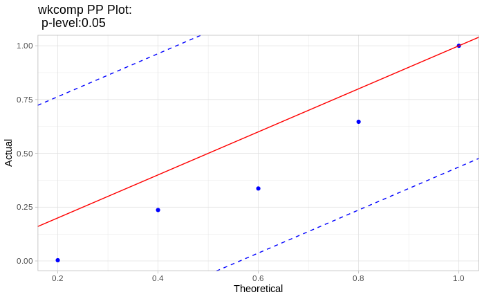

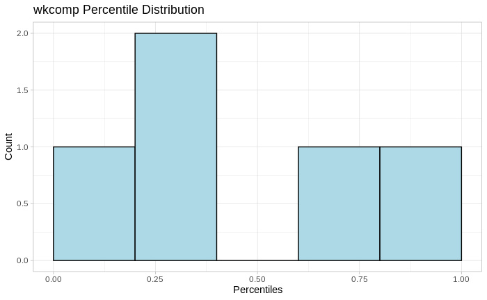

## Bootstrapped Chain Ladder

| metric | wkcomp |
| --- | --- |
| RMSE Claims | 77885.4468 |
| RMSE LR | 0.0492 |
| RMSE Weighted LR | 0.0344 |
| Coverage 90 | 0.6000 |
| CRPS1 | 196306.0155 |
| NLPD | 106.6139 |
| KS Rejection Level | 0.5633 |
| KS D | 0.2000 |
| KS Result | 0.0000 |
| Valid Count | 5.0000 |

| Step_Ahead | wkcomp |
| --- | --- |
| 1 | 20619.856 |
| 2 | 37369.914 |
| 3 | 46932.099 |
| 4 | 51576.604 |
| 5 | 51957.348 |
| 6 | 49009.731 |
| 7 | 39815.973 |
| 8 | 20755.432 |
| 9 | 2284.865 |

| Step_Ahead | wkcomp |
| --- | --- |
| 1 | 0.0013 |
| 2 | 0.0031 |
| 3 | 0.0055 |
| 4 | 0.0092 |
| 5 | 0.0154 |
| 6 | 0.0267 |
| 7 | 0.0495 |
| 8 | 0.0963 |
| 9 | 0.2477 |

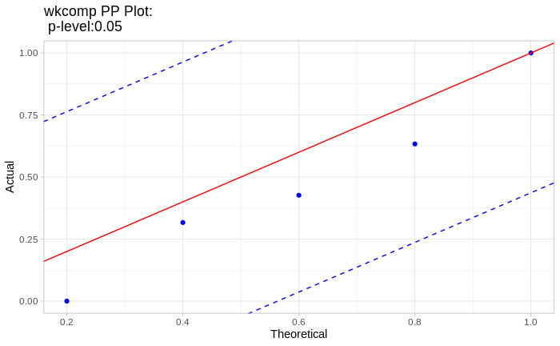

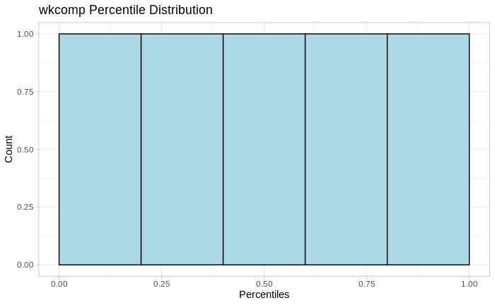

## GP on Incremental Loss Ratios with no constraints on GP using a compound kernel

| metric | wkcomp |
| --- | --- |
| RMSE Claims | 240040.4066 |
| RMSE LR | 0.1404 |
| RMSE Weighted LR | 0.1199 |
| Coverage 90 | 0.8000 |
| CRPS1 | 496115.8480 |
| NLPD | 116.4937 |
| KS Rejection Level | 0.5633 |
| KS D | 0.2900 |
| KS Result | 0.0000 |
| Valid Count | 5.0000 |

| Step_Ahead | wkcomp |
| --- | --- |
| 1 | 39903.26 |
| 2 | 79522.00 |
| 3 | 117317.57 |
| 4 | 148647.33 |
| 5 | 166616.55 |
| 6 | 171757.88 |
| 7 | 162667.51 |
| 8 | 131050.68 |
| 9 | 76847.61 |

| Step_Ahead | wkcomp |
| --- | --- |
| 1 | 0.0021 |
| 2 | 0.0051 |
| 3 | 0.0098 |
| 4 | 0.0170 |
| 5 | 0.0297 |
| 6 | 0.0509 |
| 7 | 0.0958 |
| 8 | 0.1950 |
| 9 | 0.5069 |

|  | business_line | code | par | mean | se_mean | sd | 2.5% | 25% | 50% | 75% | 97.5% | n_eff | Rhat |
| --- | --- | --- | --- | --- | --- | --- | --- | --- | --- | --- | --- | --- | --- |
| wkcomp.1 | wkcomp | 86 | eta | 0.91683020 | 0.0226410972 | 0.32115982 | 0.4465271920 | 0.694366422 | 0.86394156 | 1.07245094 | 1.79648672 | 201.2090 | 1.0008156 |
| wkcomp.2 | wkcomp | 86 | rho[1] | 1.52931059 | 0.0369254367 | 0.54957172 | 0.7588164335 | 1.154902481 | 1.43054037 | 1.78449405 | 2.92555604 | 221.5121 | 0.9989599 |
| wkcomp.3 | wkcomp | 86 | rho[2] | 1.15847192 | 0.0186221040 | 0.27188194 | 0.6952230050 | 0.960240144 | 1.11964414 | 1.32394973 | 1.70704503 | 213.1588 | 0.9968210 |
| wkcomp.4 | wkcomp | 86 | sigma[1] | 0.05942389 | 0.0027824509 | 0.04487399 | 0.0019569237 | 0.020248021 | 0.05238637 | 0.08976726 | 0.14936594 | 260.0964 | 1.0049737 |
| wkcomp.5 | wkcomp | 86 | sigma[2] | 0.13544435 | 0.0036971810 | 0.04948384 | 0.0379575322 | 0.103230062 | 0.13399434 | 0.16876636 | 0.23218245 | 179.1370 | 1.0399726 |
| wkcomp.6 | wkcomp | 86 | sigma[3] | 0.18041211 | 0.0026182763 | 0.04671048 | 0.0995266926 | 0.147298365 | 0.17365076 | 0.21019305 | 0.29165345 | 318.2715 | 1.0106998 |
| wkcomp.7 | wkcomp | 86 | sigma[4] | 0.22115892 | 0.0026880503 | 0.05280176 | 0.1463188475 | 0.181163572 | 0.21231661 | 0.25294030 | 0.32957750 | 385.8532 | 0.9981025 |
| wkcomp.8 | wkcomp | 86 | sigma[5] | 0.25859865 | 0.0033195404 | 0.06276204 | 0.1682282723 | 0.211570617 | 0.25028851 | 0.29796662 | 0.37986657 | 357.4689 | 0.9968348 |
| wkcomp.9 | wkcomp | 86 | sigma[6] | 0.31488205 | 0.0043490985 | 0.07760767 | 0.2009853261 | 0.262625785 | 0.30610541 | 0.35537584 | 0.47958186 | 318.4277 | 0.9971065 |
| wkcomp.10 | wkcomp | 86 | sigma[7] | 0.41855856 | 0.0069033396 | 0.10579656 | 0.2515410000 | 0.348203840 | 0.40071270 | 0.48685071 | 0.64817798 | 234.8684 | 1.0001578 |

[output cut: 65 more lines]

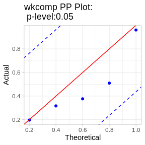

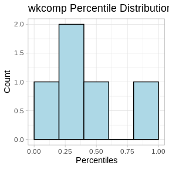

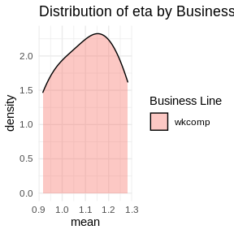

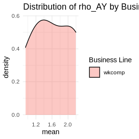

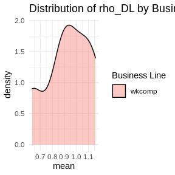

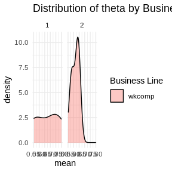

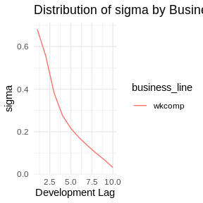

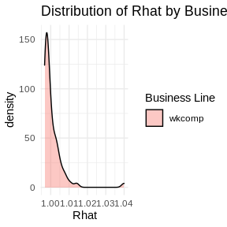

## GP on Incremental Loss Ratios with Hurdle Model with Vector mu

## GP on Incremental Loss Ratios with Hurdle Model with Vector mu, with Virtual Data